# Project: Wrangling and Analyzing Data

## Introduction

In this project, I will be using data from @WerateDog for my analysis. I will gather the data from three different sources, access it and clean it to the degree it is fit for my analysis. I will then explore the cleaned data to draw insight on dog breeds that are more popular among dog lovers.

### Note:

Import all libraries need for this project

```python
# Import neccessary libraray
import pandas as pd
import numpy as np
import requests
import json
%matplotlib inline
import matplotlib.pyplot as plt
import seaborn as sns
# import tweepy
```

## Data Gathering

### Note:

Load the twitter archive dataset to the dataframe.

```python
# Load the twitter archive dataset to the dataframe.
archive = pd.read_csv("twitter-archive-enhanced.csv")
```

```python
# Take a look at the first few rows to confirm
archive.head()
```

|  | tweet_id | in_reply_to_status_id | in_reply_to_user_id | timestamp | source | text | retweeted_status_id | retweeted_status_user_id | retweeted_status_timestamp | expanded_urls | rating_numerator | rating_denominator | name | doggo | floofer | pupper | puppo |
| --- | --- | --- | --- | --- | --- | --- | --- | --- | --- | --- | --- | --- | --- | --- | --- | --- | --- |
| 0 | 892420643555336193 | NaN | NaN | 2017-08-01 16:23:56 +0000 | <a href="http://twitter.com/download/iphone" r... | This is Phineas. He's a mystical boy. Only eve... | NaN | NaN | NaN | https://twitter.com/dog_rates/status/892420643... | 13 | 10 | Phineas | None | None | None | None |
| 1 | 892177421306343426 | NaN | NaN | 2017-08-01 00:17:27 +0000 | <a href="http://twitter.com/download/iphone" r... | This is Tilly. She's just checking pup on you.... | NaN | NaN | NaN | https://twitter.com/dog_rates/status/892177421... | 13 | 10 | Tilly | None | None | None | None |
| 2 | 891815181378084864 | NaN | NaN | 2017-07-31 00:18:03 +0000 | <a href="http://twitter.com/download/iphone" r... | This is Archie. He is a rare Norwegian Pouncin... | NaN | NaN | NaN | https://twitter.com/dog_rates/status/891815181... | 12 | 10 | Archie | None | None | None | None |
| 3 | 891689557279858688 | NaN | NaN | 2017-07-30 15:58:51 +0000 | <a href="http://twitter.com/download/iphone" r... | This is Darla. She commenced a snooze mid meal... | NaN | NaN | NaN | https://twitter.com/dog_rates/status/891689557... | 13 | 10 | Darla | None | None | None | None |
| 4 | 891327558926688256 | NaN | NaN | 2017-07-29 16:00:24 +0000 | <a href="http://twitter.com/download/iphone" r... | This is Franklin. He would like you to stop ca... | NaN | NaN | NaN | https://twitter.com/dog_rates/status/891327558... | 12 | 10 | Franklin | None | None | None | None |

### Note:

Load the image predictions dataset to the dataset using the requests library.

```python
# url
url = "https://d17h27t6h515a5.cloudfront.net/topher/2017/August/599fd2ad_image-predictions/image-predictions.tsv"
```

```python
# Requests to get url
response = requests.get(url)
```

```python
# write content to file
with open("image_file", "wb") as my_file:
    my_file.write(response.content)
```

```python
# load the created file into dataframe.
image = pd.read_csv("image_file", delimiter="\t")
```

```python
image.head(3)
```

|  | tweet_id | jpg_url | img_num | p1 | p1_conf | p1_dog | p2 | p2_conf | p2_dog | p3 | p3_conf | p3_dog |
| --- | --- | --- | --- | --- | --- | --- | --- | --- | --- | --- | --- | --- |
| 0 | 666020888022790149 | https://pbs.twimg.com/media/CT4udn0WwAA0aMy.jpg | 1 | Welsh_springer_spaniel | 0.465074 | True | collie | 0.156665 | True | Shetland_sheepdog | 0.061428 | True |
| 1 | 666029285002620928 | https://pbs.twimg.com/media/CT42GRgUYAA5iDo.jpg | 1 | redbone | 0.506826 | True | miniature_pinscher | 0.074192 | True | Rhodesian_ridgeback | 0.072010 | True |
| 2 | 666033412701032449 | https://pbs.twimg.com/media/CT4521TWwAEvMyu.jpg | 1 | German_shepherd | 0.596461 | True | malinois | 0.138584 | True | bloodhound | 0.116197 | True |

#### Note:

Gather additional twitter data.

```python
tweet = pd.read_json("tweet.json", lines=True)
```

```python
tweet.info()
```

```
<class 'pandas.core.frame.DataFrame'>
RangeIndex: 2354 entries, 0 to 2353
Data columns (total 31 columns):
 #   Column                         Non-Null Count  Dtype
---  ------                         --------------  -----
 0   created_at                     2354 non-null   datetime64[ns, UTC]
 1   id                             2354 non-null   int64
 2   id_str                         2354 non-null   int64
 3   full_text                      2354 non-null   object
 4   truncated                      2354 non-null   bool
 5   display_text_range             2354 non-null   object
 6   entities                       2354 non-null   object
 7   extended_entities              2073 non-null   object
 8   source                         2354 non-null   object
 9   in_reply_to_status_id          78 non-null     float64
```

[output cut: 23 more lines]

### Note:

The id, retweet_count and favourite_count columns are the only columns useful for the analysis. Hence, Only this data will be gathered.

```python
# Take the dataframe of this columns and store.
tweet = tweet[["id", "retweet_count", "favorite_count"]]
```

```python
# A quick look.
tweet.info()
```

```
<class 'pandas.core.frame.DataFrame'>
RangeIndex: 2354 entries, 0 to 2353
Data columns (total 3 columns):
 #   Column          Non-Null Count  Dtype
---  ------          --------------  -----
 0   id              2354 non-null   int64
 1   retweet_count   2354 non-null   int64
 2   favorite_count  2354 non-null   int64
dtypes: int64(3)
memory usage: 55.3 KB
```

## Accesing Data

In this section, I will be accesing all the datasets gathered in the Data gathering section. This will be done both visually and programmatically.

Accessing the data includes identifying and putting down both quality and tidiness issues that may be found with the datasets.

This issues will later be cleaned in the "Cleaning Data" section.

### Note:

Visually access the archive datasets, indentifying both quality and tidiness issues.

### Note:

I will set the number of rows in pandas to unlimited to be able to visually access files down the rows.

I will also use microsoft excel to visualize access data.

```python
# Display archive data

archive
```

|  | tweet_id | in_reply_to_status_id | in_reply_to_user_id | timestamp | source | text | retweeted_status_id | retweeted_status_user_id | retweeted_status_timestamp | expanded_urls | rating_numerator | rating_denominator | name | doggo | floofer | pupper | puppo |
| --- | --- | --- | --- | --- | --- | --- | --- | --- | --- | --- | --- | --- | --- | --- | --- | --- | --- |
| 0 | 892420643555336193 | NaN | NaN | 2017-08-01 16:23:56 +0000 | <a href="http://twitter.com/download/iphone" r... | This is Phineas. He's a mystical boy. Only eve... | NaN | NaN | NaN | https://twitter.com/dog_rates/status/892420643... | 13 | 10 | Phineas | None | None | None | None |
| 1 | 892177421306343426 | NaN | NaN | 2017-08-01 00:17:27 +0000 | <a href="http://twitter.com/download/iphone" r... | This is Tilly. She's just checking pup on you.... | NaN | NaN | NaN | https://twitter.com/dog_rates/status/892177421... | 13 | 10 | Tilly | None | None | None | None |
| 2 | 891815181378084864 | NaN | NaN | 2017-07-31 00:18:03 +0000 | <a href="http://twitter.com/download/iphone" r... | This is Archie. He is a rare Norwegian Pouncin... | NaN | NaN | NaN | https://twitter.com/dog_rates/status/891815181... | 12 | 10 | Archie | None | None | None | None |
| 3 | 891689557279858688 | NaN | NaN | 2017-07-30 15:58:51 +0000 | <a href="http://twitter.com/download/iphone" r... | This is Darla. She commenced a snooze mid meal... | NaN | NaN | NaN | https://twitter.com/dog_rates/status/891689557... | 13 | 10 | Darla | None | None | None | None |
| 4 | 891327558926688256 | NaN | NaN | 2017-07-29 16:00:24 +0000 | <a href="http://twitter.com/download/iphone" r... | This is Franklin. He would like you to stop ca... | NaN | NaN | NaN | https://twitter.com/dog_rates/status/891327558... | 12 | 10 | Franklin | None | None | None | None |
| ... | ... | ... | ... | ... | ... | ... | ... | ... | ... | ... | ... | ... | ... | ... | ... | ... | ... |
| 2351 | 666049248165822465 | NaN | NaN | 2015-11-16 00:24:50 +0000 | <a href="http://twitter.com/download/iphone" r... | Here we have a 1949 1st generation vulpix. Enj... | NaN | NaN | NaN | https://twitter.com/dog_rates/status/666049248... | 5 | 10 | None | None | None | None | None |
| 2352 | 666044226329800704 | NaN | NaN | 2015-11-16 00:04:52 +0000 | <a href="http://twitter.com/download/iphone" r... | This is a purebred Piers Morgan. Loves to Netf... | NaN | NaN | NaN | https://twitter.com/dog_rates/status/666044226... | 6 | 10 | a | None | None | None | None |
| 2353 | 666033412701032449 | NaN | NaN | 2015-11-15 23:21:54 +0000 | <a href="http://twitter.com/download/iphone" r... | Here is a very happy pup. Big fan of well-main... | NaN | NaN | NaN | https://twitter.com/dog_rates/status/666033412... | 9 | 10 | a | None | None | None | None |
| 2354 | 666029285002620928 | NaN | NaN | 2015-11-15 23:05:30 +0000 | <a href="http://twitter.com/download/iphone" r... | This is a western brown Mitsubishi terrier. Up... | NaN | NaN | NaN | https://twitter.com/dog_rates/status/666029285... | 7 | 10 | a | None | None | None | None |
| 2355 | 666020888022790149 | NaN | NaN | 2015-11-15 22:32:08 +0000 | <a href="http://twitter.com/download/iphone" r... | Here we have a Japanese Irish Setter. Lost eye... | NaN | NaN | NaN | https://twitter.com/dog_rates/status/666020888... | 8 | 10 | None | None | None | None | None |

2356 rows × 17 columns

### Note:

In the next set of cells, I will be accessing the twitter archive data programmatically.

```python
# Check archive information programmably to access data for data type,
# number of rows and column and missing data.

archive.info()
```

```
<class 'pandas.core.frame.DataFrame'>
RangeIndex: 2356 entries, 0 to 2355
Data columns (total 17 columns):
 #   Column                      Non-Null Count  Dtype
---  ------                      --------------  -----
 0   tweet_id                    2356 non-null   int64
 1   in_reply_to_status_id       78 non-null     float64
 2   in_reply_to_user_id         78 non-null     float64
 3   timestamp                   2356 non-null   object
 4   source                      2356 non-null   object
 5   text                        2356 non-null   object
 6   retweeted_status_id         181 non-null    float64
 7   retweeted_status_user_id    181 non-null    float64
 8   retweeted_status_timestamp  181 non-null    object
 9   expanded_urls               2297 non-null   object
 10  rating_numerator            2356 non-null   int64
 11  rating_denominator          2356 non-null   int64
 12  name                        2356 non-null   object
 13  doggo                       2356 non-null   object
 14  floofer                     2356 non-null   object
 15  pupper                      2356 non-null   object
 16  puppo                       2356 non-null   object
dtypes: float64(4), int64(3), object(10)
memory usage: 313.0+ KB
```

```python
# Access integer data for incorrect data such as outliers and the likes.

archive.describe()
```

|  | tweet_id | in_reply_to_status_id | in_reply_to_user_id | retweeted_status_id | retweeted_status_user_id | rating_numerator | rating_denominator |
| --- | --- | --- | --- | --- | --- | --- | --- |
| count | 2.356000e+03 | 7.800000e+01 | 7.800000e+01 | 1.810000e+02 | 1.810000e+02 | 2356.000000 | 2356.000000 |
| mean | 7.427716e+17 | 7.455079e+17 | 2.014171e+16 | 7.720400e+17 | 1.241698e+16 | 13.126486 | 10.455433 |
| std | 6.856705e+16 | 7.582492e+16 | 1.252797e+17 | 6.236928e+16 | 9.599254e+16 | 45.876648 | 6.745237 |
| min | 6.660209e+17 | 6.658147e+17 | 1.185634e+07 | 6.661041e+17 | 7.832140e+05 | 0.000000 | 0.000000 |
| 25% | 6.783989e+17 | 6.757419e+17 | 3.086374e+08 | 7.186315e+17 | 4.196984e+09 | 10.000000 | 10.000000 |
| 50% | 7.196279e+17 | 7.038708e+17 | 4.196984e+09 | 7.804657e+17 | 4.196984e+09 | 11.000000 | 10.000000 |
| 75% | 7.993373e+17 | 8.257804e+17 | 4.196984e+09 | 8.203146e+17 | 4.196984e+09 | 12.000000 | 10.000000 |
| max | 8.924206e+17 | 8.862664e+17 | 8.405479e+17 | 8.874740e+17 | 7.874618e+17 | 1776.000000 | 170.000000 |

```python
# Access data for the unique values of rating denominator for values other than 10.

archive["rating_denominator"].value_counts()
```

```
10     2333
11        3
50        3
20        2
80        2
70        1
7         1
15        1
150       1
170       1
0         1
90        1
40        1
130       1
110       1
16        1
120       1
2         1
Name: rating_denominator, dtype: int64
```

```python
# Check for the number of data that has the rating_numerator less than or equal to rating_denominator.

(archive["rating_numerator"] <= archive["rating_denominator"]).value_counts()
```

```
False    1451
True      905
dtype: int64
```

```python
# Check for the number of data that has the rating_numerator less than 10.


(archive["rating_numerator"] <10).value_counts()
```

```
False    1916
True      440
Name: rating_numerator, dtype: int64
```

```python
# Check for the number of data that has the rating_denominator not equal to 10.

(archive["rating_denominator"] !=10).value_counts()
```

```
False    2333
True       23
Name: rating_denominator, dtype: int64
```

```python
# Check for the number of data that has the rating_denominator greater than 10.
archive[archive["rating_denominator"] > 10]
```

|  | tweet_id | in_reply_to_status_id | in_reply_to_user_id | timestamp | source | text | retweeted_status_id | retweeted_status_user_id | retweeted_status_timestamp | expanded_urls | rating_numerator | rating_denominator | name | doggo | floofer | pupper | puppo |
| --- | --- | --- | --- | --- | --- | --- | --- | --- | --- | --- | --- | --- | --- | --- | --- | --- | --- |
| 342 | 832088576586297345 | 8.320875e+17 | 3.058208e+07 | 2017-02-16 04:45:50 +0000 | <a href="http://twitter.com/download/iphone" r... | @docmisterio account started on 11/15/15 | NaN | NaN | NaN | NaN | 11 | 15 | None | None | None | None | None |
| 433 | 820690176645140481 | NaN | NaN | 2017-01-15 17:52:40 +0000 | <a href="http://twitter.com/download/iphone" r... | The floofs have been released I repeat the flo... | NaN | NaN | NaN | https://twitter.com/dog_rates/status/820690176... | 84 | 70 | None | None | None | None | None |
| 784 | 775096608509886464 | NaN | NaN | 2016-09-11 22:20:06 +0000 | <a href="http://twitter.com/download/iphone" r... | RT @dog_rates: After so many requests, this is... | 7.403732e+17 | 4.196984e+09 | 2016-06-08 02:41:38 +0000 | https://twitter.com/dog_rates/status/740373189... | 9 | 11 | None | None | None | None | None |
| 902 | 758467244762497024 | NaN | NaN | 2016-07-28 01:00:57 +0000 | <a href="http://twitter.com/download/iphone" r... | Why does this never happen at my front door...... | NaN | NaN | NaN | https://twitter.com/dog_rates/status/758467244... | 165 | 150 | None | None | None | None | None |
| 1068 | 740373189193256964 | NaN | NaN | 2016-06-08 02:41:38 +0000 | <a href="http://twitter.com/download/iphone" r... | After so many requests, this is Bretagne. She ... | NaN | NaN | NaN | https://twitter.com/dog_rates/status/740373189... | 9 | 11 | None | None | None | None | None |
| 1120 | 731156023742988288 | NaN | NaN | 2016-05-13 16:15:54 +0000 | <a href="http://twitter.com/download/iphone" r... | Say hello to this unbelievably well behaved sq... | NaN | NaN | NaN | https://twitter.com/dog_rates/status/731156023... | 204 | 170 | this | None | None | None | None |
| 1165 | 722974582966214656 | NaN | NaN | 2016-04-21 02:25:47 +0000 | <a href="http://twitter.com/download/iphone" r... | Happy 4/20 from the squad! 13/10 for all https... | NaN | NaN | NaN | https://twitter.com/dog_rates/status/722974582... | 4 | 20 | None | None | None | None | None |
| 1202 | 716439118184652801 | NaN | NaN | 2016-04-03 01:36:11 +0000 | <a href="http://twitter.com/download/iphone" r... | This is Bluebert. He just saw that both #Final... | NaN | NaN | NaN | https://twitter.com/dog_rates/status/716439118... | 50 | 50 | Bluebert | None | None | None | None |
| 1228 | 713900603437621249 | NaN | NaN | 2016-03-27 01:29:02 +0000 | <a href="http://twitter.com/download/iphone" r... | Happy Saturday here's 9 puppers on a bench. 99... | NaN | NaN | NaN | https://twitter.com/dog_rates/status/713900603... | 99 | 90 | None | None | None | None | None |
| 1254 | 710658690886586372 | NaN | NaN | 2016-03-18 02:46:49 +0000 | <a href="http://twitter.com/download/iphone" r... | Here's a brigade of puppers. All look very pre... | NaN | NaN | NaN | https://twitter.com/dog_rates/status/710658690... | 80 | 80 | None | None | None | None | None |
| 1274 | 709198395643068416 | NaN | NaN | 2016-03-14 02:04:08 +0000 | <a href="http://twitter.com/download/iphone" r... | From left to right:\nCletus, Jerome, Alejandro... | NaN | NaN | NaN | https://twitter.com/dog_rates/status/709198395... | 45 | 50 | None | None | None | None | None |
| 1351 | 704054845121142784 | NaN | NaN | 2016-02-28 21:25:30 +0000 | <a href="http://twitter.com/download/iphone" r... | Here is a whole flock of puppers. 60/50 I'll ... | NaN | NaN | NaN | https://twitter.com/dog_rates/status/704054845... | 60 | 50 | a | None | None | None | None |
| 1433 | 697463031882764288 | NaN | NaN | 2016-02-10 16:51:59 +0000 | <a href="http://twitter.com/download/iphone" r... | Happy Wednesday here's a bucket of pups. 44/40... | NaN | NaN | NaN | https://twitter.com/dog_rates/status/697463031... | 44 | 40 | None | None | None | None | None |
| 1598 | 686035780142297088 | 6.860340e+17 | 4.196984e+09 | 2016-01-10 04:04:10 +0000 | <a href="http://twitter.com/download/iphone" r... | Yes I do realize a rating of 4/20 would've bee... | NaN | NaN | NaN | NaN | 4 | 20 | None | None | None | None | None |
| 1634 | 684225744407494656 | 6.842229e+17 | 4.196984e+09 | 2016-01-05 04:11:44 +0000 | <a href="http://twitter.com/download/iphone" r... | Two sneaky puppers were not initially seen, mo... | NaN | NaN | NaN | https://twitter.com/dog_rates/status/684225744... | 143 | 130 | None | None | None | None | None |
| 1635 | 684222868335505415 | NaN | NaN | 2016-01-05 04:00:18 +0000 | <a href="http://twitter.com/download/iphone" r... | Someone help the girl is being mugged. Several... | NaN | NaN | NaN | https://twitter.com/dog_rates/status/684222868... | 121 | 110 | None | None | None | None | None |
| 1662 | 682962037429899265 | NaN | NaN | 2016-01-01 16:30:13 +0000 | <a href="http://twitter.com/download/iphone" r... | This is Darrel. He just robbed a 7/11 and is i... | NaN | NaN | NaN | https://twitter.com/dog_rates/status/682962037... | 7 | 11 | Darrel | None | None | None | None |
| 1663 | 682808988178739200 | 6.827884e+17 | 4.196984e+09 | 2016-01-01 06:22:03 +0000 | <a href="http://twitter.com/download/iphone" r... | I'm aware that I could've said 20/16, but here... | NaN | NaN | NaN | NaN | 20 | 16 | None | None | None | None | None |
| 1779 | 677716515794329600 | NaN | NaN | 2015-12-18 05:06:23 +0000 | <a href="http://twitter.com/download/iphone" r... | IT'S PUPPERGEDDON. Total of 144/120 ...I think... | NaN | NaN | NaN | https://twitter.com/dog_rates/status/677716515... | 144 | 120 | None | None | None | None | None |
| 1843 | 675853064436391936 | NaN | NaN | 2015-12-13 01:41:41 +0000 | <a href="http://twitter.com/download/iphone" r... | Here we have an entire platoon of puppers. Tot... | NaN | NaN | NaN | https://twitter.com/dog_rates/status/675853064... | 88 | 80 | None | None | None | None | None |

```python
# Access the names of dogs for missing value, wrong spelling and incorrect data

archive["name"]
```

```
0        Phineas
1          Tilly
2         Archie
3          Darla
4       Franklin
          ...
2351        None
2352           a
2353           a
2354           a
2355        None
Name: name, Length: 2356, dtype: object
```

```python
# Check the number of floofers in the floofer column.

archive["floofer"].value_counts()
```

```
None       2346
floofer      10
Name: floofer, dtype: int64
```

```python
# Access p1 column for unique values and errors in data.

archive["source"].value_counts()
```

```
<a href="http://twitter.com/download/iphone" rel="nofollow">Twitter for iPhone</a>     2221
<a href="http://vine.co" rel="nofollow">Vine - Make a Scene</a>                          91
<a href="http://twitter.com" rel="nofollow">Twitter Web Client</a>                       33
<a href="https://about.twitter.com/products/tweetdeck" rel="nofollow">TweetDeck</a>      11
Name: source, dtype: int64
```

```python
# Visually access in_reply_to_user_id for missing and incorrect data.
archive["in_reply_to_user_id"]
```

```
0      NaN
1      NaN
2      NaN
3      NaN
4      NaN
        ..
2351   NaN
2352   NaN
2353   NaN
2354   NaN
2355   NaN
Name: in_reply_to_user_id, Length: 2356, dtype: float64
```

### Note:

Visual assessment of image information data in the following cell

```python
image
```

|  | tweet_id | jpg_url | img_num | p1 | p1_conf | p1_dog | p2 | p2_conf | p2_dog | p3 | p3_conf | p3_dog |
| --- | --- | --- | --- | --- | --- | --- | --- | --- | --- | --- | --- | --- |
| 0 | 666020888022790149 | https://pbs.twimg.com/media/CT4udn0WwAA0aMy.jpg | 1 | Welsh_springer_spaniel | 0.465074 | True | collie | 0.156665 | True | Shetland_sheepdog | 0.061428 | True |
| 1 | 666029285002620928 | https://pbs.twimg.com/media/CT42GRgUYAA5iDo.jpg | 1 | redbone | 0.506826 | True | miniature_pinscher | 0.074192 | True | Rhodesian_ridgeback | 0.072010 | True |
| 2 | 666033412701032449 | https://pbs.twimg.com/media/CT4521TWwAEvMyu.jpg | 1 | German_shepherd | 0.596461 | True | malinois | 0.138584 | True | bloodhound | 0.116197 | True |
| 3 | 666044226329800704 | https://pbs.twimg.com/media/CT5Dr8HUEAA-lEu.jpg | 1 | Rhodesian_ridgeback | 0.408143 | True | redbone | 0.360687 | True | miniature_pinscher | 0.222752 | True |
| 4 | 666049248165822465 | https://pbs.twimg.com/media/CT5IQmsXIAAKY4A.jpg | 1 | miniature_pinscher | 0.560311 | True | Rottweiler | 0.243682 | True | Doberman | 0.154629 | True |
| ... | ... | ... | ... | ... | ... | ... | ... | ... | ... | ... | ... | ... |
| 2070 | 891327558926688256 | https://pbs.twimg.com/media/DF6hr6BUMAAzZgT.jpg | 2 | basset | 0.555712 | True | English_springer | 0.225770 | True | German_short-haired_pointer | 0.175219 | True |
| 2071 | 891689557279858688 | https://pbs.twimg.com/media/DF_q7IAWsAEuuN8.jpg | 1 | paper_towel | 0.170278 | False | Labrador_retriever | 0.168086 | True | spatula | 0.040836 | False |
| 2072 | 891815181378084864 | https://pbs.twimg.com/media/DGBdLU1WsAANxJ9.jpg | 1 | Chihuahua | 0.716012 | True | malamute | 0.078253 | True | kelpie | 0.031379 | True |
| 2073 | 892177421306343426 | https://pbs.twimg.com/media/DGGmoV4XsAAUL6n.jpg | 1 | Chihuahua | 0.323581 | True | Pekinese | 0.090647 | True | papillon | 0.068957 | True |
| 2074 | 892420643555336193 | https://pbs.twimg.com/media/DGKD1-bXoAAIAUK.jpg | 1 | orange | 0.097049 | False | bagel | 0.085851 | False | banana | 0.076110 | False |

2075 rows × 12 columns

### Note:

Programmatic assessment of image information data in the following cell

```python
# Check image information programmably to access data for data type,
# number of rows and columns and missing data.

image.info()
```

```
<class 'pandas.core.frame.DataFrame'>
RangeIndex: 2075 entries, 0 to 2074
Data columns (total 12 columns):
 #   Column    Non-Null Count  Dtype
---  ------    --------------  -----
 0   tweet_id  2075 non-null   int64
 1   jpg_url   2075 non-null   object
 2   img_num   2075 non-null   int64
 3   p1        2075 non-null   object
 4   p1_conf   2075 non-null   float64
 5   p1_dog    2075 non-null   bool
 6   p2        2075 non-null   object
 7   p2_conf   2075 non-null   float64
 8   p2_dog    2075 non-null   bool
 9   p3        2075 non-null   object
 10  p3_conf   2075 non-null   float64
 11  p3_dog    2075 non-null   bool
dtypes: bool(3), float64(3), int64(2), object(4)
memory usage: 152.1+ KB
```

```python
# Access integer data for incorrect data such as outliers and the likes.

image.describe()
```

|  | tweet_id | img_num | p1_conf | p2_conf | p3_conf |
| --- | --- | --- | --- | --- | --- |
| count | 2.075000e+03 | 2075.000000 | 2075.000000 | 2.075000e+03 | 2.075000e+03 |
| mean | 7.384514e+17 | 1.203855 | 0.594548 | 1.345886e-01 | 6.032417e-02 |
| std | 6.785203e+16 | 0.561875 | 0.271174 | 1.006657e-01 | 5.090593e-02 |
| min | 6.660209e+17 | 1.000000 | 0.044333 | 1.011300e-08 | 1.740170e-10 |
| 25% | 6.764835e+17 | 1.000000 | 0.364412 | 5.388625e-02 | 1.622240e-02 |
| 50% | 7.119988e+17 | 1.000000 | 0.588230 | 1.181810e-01 | 4.944380e-02 |
| 75% | 7.932034e+17 | 1.000000 | 0.843855 | 1.955655e-01 | 9.180755e-02 |
| max | 8.924206e+17 | 4.000000 | 1.000000 | 4.880140e-01 | 2.734190e-01 |

```python
# Access p1 column for unique values and errors in data.

image["p1"].value_counts()
```

```
golden_retriever      150
Labrador_retriever    100
Pembroke               89
Chihuahua              83
pug                    57
                     ...
pillow                  1
carousel                1
bald_eagle              1
lorikeet                1
orange                  1
Name: p1, Length: 378, dtype: int64
```

### Note:

Visually access the tweet dataset, indentifying both quality and tidiness issues.

```python
tweet
```

|  | id | retweet_count | favorite_count |
| --- | --- | --- | --- |
| 0 | 892420643555336193 | 8853 | 39467 |
| 1 | 892177421306343426 | 6514 | 33819 |
| 2 | 891815181378084864 | 4328 | 25461 |
| 3 | 891689557279858688 | 8964 | 42908 |
| 4 | 891327558926688256 | 9774 | 41048 |
| ... | ... | ... | ... |
| 2349 | 666049248165822465 | 41 | 111 |
| 2350 | 666044226329800704 | 147 | 311 |
| 2351 | 666033412701032449 | 47 | 128 |
| 2352 | 666029285002620928 | 48 | 132 |
| 2353 | 666020888022790149 | 532 | 2535 |

2354 rows × 3 columns

### Note:

In the next set of ceells, I will be accessing the tweet data using programmatical means.

```python
# Check tweet information programmably to access data for data type.
# number of rows and column and missing data.

tweet.info()
```

```
<class 'pandas.core.frame.DataFrame'>
RangeIndex: 2354 entries, 0 to 2353
Data columns (total 3 columns):
 #   Column          Non-Null Count  Dtype
---  ------          --------------  -----
 0   id              2354 non-null   int64
 1   retweet_count   2354 non-null   int64
 2   favorite_count  2354 non-null   int64
dtypes: int64(3)
memory usage: 55.3 KB
```

```python
# Access integer data for incorrect data such as outliers and the likes.
# Also for statistical summary of data.
tweet.describe()
```

|  | id | retweet_count | favorite_count |
| --- | --- | --- | --- |
| count | 2.354000e+03 | 2354.000000 | 2354.000000 |
| mean | 7.426978e+17 | 3164.797366 | 8080.968564 |
| std | 6.852812e+16 | 5284.770364 | 11814.771334 |
| min | 6.660209e+17 | 0.000000 | 0.000000 |
| 25% | 6.783975e+17 | 624.500000 | 1415.000000 |
| 50% | 7.194596e+17 | 1473.500000 | 3603.500000 |
| 75% | 7.993058e+17 | 3652.000000 | 10122.250000 |
| max | 8.924206e+17 | 79515.000000 | 132810.000000 |

```python
archive[archive["rating_numerator"]  == archive["rating_numerator"].max()]
```

|  | tweet_id | in_reply_to_status_id | in_reply_to_user_id | timestamp | source | text | retweeted_status_id | retweeted_status_user_id | retweeted_status_timestamp | expanded_urls | rating_numerator | rating_denominator | name | doggo | floofer | pupper | puppo |
| --- | --- | --- | --- | --- | --- | --- | --- | --- | --- | --- | --- | --- | --- | --- | --- | --- | --- |
| 979 | 749981277374128128 | NaN | NaN | 2016-07-04 15:00:45 +0000 | <a href="https://about.twitter.com/products/tw... | This is Atticus. He's quite simply America af.... | NaN | NaN | NaN | https://twitter.com/dog_rates/status/749981277... | 1776 | 10 | Atticus | None | None | None | None |

### Note:

I highlight below the issues found with the datasets. These issues comprises both quality and tidiness issues(messy and untidy data). This issues were discovered through visual and programmatic assessments. The issues will be cleaned in the data cleaning sections.

### Quality issues.

#### Image prediction:

- Tweet id is in integer format instead of string.

#### Tweet:

- The id is in integer data type instead of string data type.
- favourite_retweet is not simple enough to describe the column name. total_retweet will be better.
- favourite_count is not simple enough to describe the column name. total_likes will be better.

### Tidiness issues

- The dog_stages columns: floofer, doggo, pupper and poppo are in different columns instead of one.
- In the image prediction dataset, there are too many columns about the strength of the predictions.
  - Cleaning should be performed on these prediction columns(p1,p1_conf, p1_dog p2, etc..) to produce a resultant outcome of fewer columns.
- Tweet id appears in all the datasets instead of one.
  - It's understandable because it will be useful for merging the datasets. Only one tweet_id data will be retained after merging. Other ones will be dropped.

The following columns were dropped from the image dataset after the result of the prediction data(p1, p1_conf, p1_dog, p2, etc.) were used to separate dog records from non-dog records.

- jpg_url
- img_num
- p1
- p1_conf
- p1_dog
- p2
- p2_conf
- p2_dog
- p3
- p3_conf
- p3_dog

Other columns dropped include:

- prediction
- name
- dog_stage
- source
- date

## Data Cleaning

### Take a copy of all the three datasets for cleaning purpose

```python
archive_clean = archive.copy()
image_clean = image.copy()
tweet_clean = tweet.copy()
```

### Missing Data

The instruction states that retweeted tweets should be excluded from the analysis. Such data will be dropped.

### Define

Drop every rows that contains retweeted status id.

### Code:

```python
# Check the data information for name of column  before dropping.
archive_clean.info()
```

```
<class 'pandas.core.frame.DataFrame'>
RangeIndex: 2356 entries, 0 to 2355
Data columns (total 17 columns):
 #   Column                      Non-Null Count  Dtype
---  ------                      --------------  -----
 0   tweet_id                    2356 non-null   int64
 1   in_reply_to_status_id       78 non-null     float64
 2   in_reply_to_user_id         78 non-null     float64
 3   timestamp                   2356 non-null   object
 4   source                      2356 non-null   object
 5   text                        2356 non-null   object
 6   retweeted_status_id         181 non-null    float64
 7   retweeted_status_user_id    181 non-null    float64
 8   retweeted_status_timestamp  181 non-null    object
 9   expanded_urls               2297 non-null   object
 10  rating_numerator            2356 non-null   int64
 11  rating_denominator          2356 non-null   int64
 12  name                        2356 non-null   object
 13  doggo                       2356 non-null   object
 14  floofer                     2356 non-null   object
 15  pupper                      2356 non-null   object
 16  puppo                       2356 non-null   object
dtypes: float64(4), int64(3), object(10)
memory usage: 313.0+ KB
```

```python
# Drop every rows that contains retweeted status id

archive_clean = archive_clean[~archive_clean["retweeted_status_id"].notnull()]
```

### Test

```python
# Confirm result.
archive_clean.info()
```

```
<class 'pandas.core.frame.DataFrame'>
Int64Index: 2175 entries, 0 to 2355
Data columns (total 17 columns):
 #   Column                      Non-Null Count  Dtype
---  ------                      --------------  -----
 0   tweet_id                    2175 non-null   int64
 1   in_reply_to_status_id       78 non-null     float64
 2   in_reply_to_user_id         78 non-null     float64
 3   timestamp                   2175 non-null   object
 4   source                      2175 non-null   object
 5   text                        2175 non-null   object
 6   retweeted_status_id         0 non-null      float64
 7   retweeted_status_user_id    0 non-null      float64
 8   retweeted_status_timestamp  0 non-null      object
 9   expanded_urls               2117 non-null   object
 10  rating_numerator            2175 non-null   int64
 11  rating_denominator          2175 non-null   int64
 12  name                        2175 non-null   object
 13  doggo                       2175 non-null   object
 14  floofer                     2175 non-null   object
 15  pupper                      2175 non-null   object
 16  puppo                       2175 non-null   object
dtypes: float64(4), int64(3), object(10)
memory usage: 305.9+ KB
```

```python
# Visually confirm the result.
archive_clean.head(500)
```

|  | tweet_id | in_reply_to_status_id | in_reply_to_user_id | timestamp | source | text | retweeted_status_id | retweeted_status_user_id | retweeted_status_timestamp | expanded_urls | rating_numerator | rating_denominator | name | doggo | floofer | pupper | puppo |
| --- | --- | --- | --- | --- | --- | --- | --- | --- | --- | --- | --- | --- | --- | --- | --- | --- | --- |
| 0 | 892420643555336193 | NaN | NaN | 2017-08-01 16:23:56 +0000 | <a href="http://twitter.com/download/iphone" r... | This is Phineas. He's a mystical boy. Only eve... | NaN | NaN | NaN | https://twitter.com/dog_rates/status/892420643... | 13 | 10 | Phineas | None | None | None | None |
| 1 | 892177421306343426 | NaN | NaN | 2017-08-01 00:17:27 +0000 | <a href="http://twitter.com/download/iphone" r... | This is Tilly. She's just checking pup on you.... | NaN | NaN | NaN | https://twitter.com/dog_rates/status/892177421... | 13 | 10 | Tilly | None | None | None | None |
| 2 | 891815181378084864 | NaN | NaN | 2017-07-31 00:18:03 +0000 | <a href="http://twitter.com/download/iphone" r... | This is Archie. He is a rare Norwegian Pouncin... | NaN | NaN | NaN | https://twitter.com/dog_rates/status/891815181... | 12 | 10 | Archie | None | None | None | None |
| 3 | 891689557279858688 | NaN | NaN | 2017-07-30 15:58:51 +0000 | <a href="http://twitter.com/download/iphone" r... | This is Darla. She commenced a snooze mid meal... | NaN | NaN | NaN | https://twitter.com/dog_rates/status/891689557... | 13 | 10 | Darla | None | None | None | None |
| 4 | 891327558926688256 | NaN | NaN | 2017-07-29 16:00:24 +0000 | <a href="http://twitter.com/download/iphone" r... | This is Franklin. He would like you to stop ca... | NaN | NaN | NaN | https://twitter.com/dog_rates/status/891327558... | 12 | 10 | Franklin | None | None | None | None |
| ... | ... | ... | ... | ... | ... | ... | ... | ... | ... | ... | ... | ... | ... | ... | ... | ... | ... |
| 616 | 796484825502875648 | NaN | NaN | 2016-11-09 22:49:15 +0000 | <a href="http://twitter.com/download/iphone" r... | Here's a sleepy doggo that requested some assi... | NaN | NaN | NaN | https://twitter.com/dog_rates/status/796484825... | 12 | 10 | None | doggo | None | None | None |
| 617 | 796387464403357696 | NaN | NaN | 2016-11-09 16:22:22 +0000 | <a href="http://twitter.com/download/iphone" r... | This is Snicku. He's having trouble reading be... | NaN | NaN | NaN | https://twitter.com/dog_rates/status/796387464... | 12 | 10 | Snicku | None | None | None | None |
| 619 | 796149749086875649 | NaN | NaN | 2016-11-09 00:37:46 +0000 | <a href="http://twitter.com/download/iphone" r... | This is Ruby. She just turned on the news. Off... | NaN | NaN | NaN | https://twitter.com/dog_rates/status/796149749... | 11 | 10 | Ruby | None | None | None | None |
| 620 | 796125600683540480 | NaN | NaN | 2016-11-08 23:01:49 +0000 | <a href="http://twitter.com/download/iphone" r... | #ImWithThor 13/10\nhttps://t.co/a18mzkhTf6 | NaN | NaN | NaN | https://twitter.com/king5seattle/status/796123... | 13 | 10 | None | None | None | None | None |
| 621 | 796116448414461957 | NaN | NaN | 2016-11-08 22:25:27 +0000 | <a href="http://twitter.com/download/iphone" r... | I didn't believe it at first but now I can see... | NaN | NaN | NaN | https://twitter.com/dog_rates/status/796116448... | 11 | 10 | None | None | None | None | None |

500 rows × 17 columns

### Fixing missing data:

The instruction says to only consider tweet with images. expanded_urls column contains links of tweets with images.

### Define

I will be taking out only the tweet data with images for analysis. This implies that tweets data with no images are dropped.

### Code

```python
# Take out the data with no missing image data.
archive_clean = archive_clean[archive_clean["expanded_urls"].notnull()]
```

### Test

```python
# Check the new the dataset for null values.
archive_clean["expanded_urls"].isnull().sum()

# A result of zero confirms we now have only tweets with images.
```

```
0
```

```python
# Check data information to confirm.
archive_clean.info()
```

```
<class 'pandas.core.frame.DataFrame'>
Int64Index: 2117 entries, 0 to 2355
Data columns (total 17 columns):
 #   Column                      Non-Null Count  Dtype
---  ------                      --------------  -----
 0   tweet_id                    2117 non-null   int64
 1   in_reply_to_status_id       23 non-null     float64
 2   in_reply_to_user_id         23 non-null     float64
 3   timestamp                   2117 non-null   object
 4   source                      2117 non-null   object
 5   text                        2117 non-null   object
 6   retweeted_status_id         0 non-null      float64
 7   retweeted_status_user_id    0 non-null      float64
 8   retweeted_status_timestamp  0 non-null      object
 9   expanded_urls               2117 non-null   object
 10  rating_numerator            2117 non-null   int64
 11  rating_denominator          2117 non-null   int64
 12  name                        2117 non-null   object
 13  doggo                       2117 non-null   object
 14  floofer                     2117 non-null   object
 15  pupper                      2117 non-null   object
 16  puppo                       2117 non-null   object
dtypes: float64(4), int64(3), object(10)
memory usage: 297.7+ KB
```

### Tidiness

The dog_stages columns: floofer, doggo, pupper and poppo are in different columns instead of one.

### Define

Combine the values of the dog stages to form one column

### Code

```python
archive_clean[["doggo", "floofer", "pupper", "puppo"]].value_counts()
```

```
doggo  floofer  pupper  puppo
None   None     None    None     1779
                pupper  None      222
doggo  None     None    None       72
None   None     None    puppo      23
doggo  None     pupper  None       10
None   floofer  None    None        9
doggo  None     None    puppo       1
       floofer  None    None        1
dtype: int64
```

```python
# Write a function with two parameters.
def drop_col(dframe, row_col, axis=0):
    dframe.drop(row_col, axis=axis, inplace=True)
```

```python
# A list of dog stages
dog_stages = ['doggo', 'floofer', 'pupper', 'puppo']

# Replace none with non values after creating a new column for dog stages.

archive_clean[dog_stages] = archive_clean[dog_stages].replace('None', np.nan)
#twitter_archive_clean[['doggo', 'floofer', 'pupper', 'puppo']]

def join_all(x):
    return ', '.join(x.dropna().astype(str))

    [[ 'floofer' , 'puppo']] ['','floofer','', 'puppo'] = [' ,floofer, ,puppo']

archive_clean['dog_stages'] = archive_clean[dog_stages].apply(join_all, axis=1)

# Replace empty string with non values.
archive_clean['dog_stages'] = archive_clean['dog_stages'].replace('', np.nan)
```

```python
# Drop these columns : doggo, floofer, pupper, puppo
drop_col(archive_clean, dog_stages, axis=1)
```

### Test

```python
# Check data information to confirm.
archive_clean.info()
```

```
<class 'pandas.core.frame.DataFrame'>
Int64Index: 2117 entries, 0 to 2355
Data columns (total 14 columns):
 #   Column                      Non-Null Count  Dtype
---  ------                      --------------  -----
 0   tweet_id                    2117 non-null   int64
 1   in_reply_to_status_id       23 non-null     float64
 2   in_reply_to_user_id         23 non-null     float64
 3   timestamp                   2117 non-null   object
 4   source                      2117 non-null   object
 5   text                        2117 non-null   object
 6   retweeted_status_id         0 non-null      float64
 7   retweeted_status_user_id    0 non-null      float64
 8   retweeted_status_timestamp  0 non-null      object
 9   expanded_urls               2117 non-null   object
 10  rating_numerator            2117 non-null   int64
 11  rating_denominator          2117 non-null   int64
 12  name                        2117 non-null   object
 13  dog_stages                  338 non-null    object
dtypes: float64(4), int64(3), object(7)
memory usage: 248.1+ KB
```

```python
# Visually check the dog_stages column for changes
archive_clean
```

|  | tweet_id | in_reply_to_status_id | in_reply_to_user_id | timestamp | source | text | retweeted_status_id | retweeted_status_user_id | retweeted_status_timestamp | expanded_urls | rating_numerator | rating_denominator | name | dog_stages |
| --- | --- | --- | --- | --- | --- | --- | --- | --- | --- | --- | --- | --- | --- | --- |
| 0 | 892420643555336193 | NaN | NaN | 2017-08-01 16:23:56 +0000 | <a href="http://twitter.com/download/iphone" r... | This is Phineas. He's a mystical boy. Only eve... | NaN | NaN | NaN | https://twitter.com/dog_rates/status/892420643... | 13 | 10 | Phineas | NaN |
| 1 | 892177421306343426 | NaN | NaN | 2017-08-01 00:17:27 +0000 | <a href="http://twitter.com/download/iphone" r... | This is Tilly. She's just checking pup on you.... | NaN | NaN | NaN | https://twitter.com/dog_rates/status/892177421... | 13 | 10 | Tilly | NaN |
| 2 | 891815181378084864 | NaN | NaN | 2017-07-31 00:18:03 +0000 | <a href="http://twitter.com/download/iphone" r... | This is Archie. He is a rare Norwegian Pouncin... | NaN | NaN | NaN | https://twitter.com/dog_rates/status/891815181... | 12 | 10 | Archie | NaN |
| 3 | 891689557279858688 | NaN | NaN | 2017-07-30 15:58:51 +0000 | <a href="http://twitter.com/download/iphone" r... | This is Darla. She commenced a snooze mid meal... | NaN | NaN | NaN | https://twitter.com/dog_rates/status/891689557... | 13 | 10 | Darla | NaN |
| 4 | 891327558926688256 | NaN | NaN | 2017-07-29 16:00:24 +0000 | <a href="http://twitter.com/download/iphone" r... | This is Franklin. He would like you to stop ca... | NaN | NaN | NaN | https://twitter.com/dog_rates/status/891327558... | 12 | 10 | Franklin | NaN |
| ... | ... | ... | ... | ... | ... | ... | ... | ... | ... | ... | ... | ... | ... | ... |
| 2351 | 666049248165822465 | NaN | NaN | 2015-11-16 00:24:50 +0000 | <a href="http://twitter.com/download/iphone" r... | Here we have a 1949 1st generation vulpix. Enj... | NaN | NaN | NaN | https://twitter.com/dog_rates/status/666049248... | 5 | 10 | None | NaN |
| 2352 | 666044226329800704 | NaN | NaN | 2015-11-16 00:04:52 +0000 | <a href="http://twitter.com/download/iphone" r... | This is a purebred Piers Morgan. Loves to Netf... | NaN | NaN | NaN | https://twitter.com/dog_rates/status/666044226... | 6 | 10 | a | NaN |
| 2353 | 666033412701032449 | NaN | NaN | 2015-11-15 23:21:54 +0000 | <a href="http://twitter.com/download/iphone" r... | Here is a very happy pup. Big fan of well-main... | NaN | NaN | NaN | https://twitter.com/dog_rates/status/666033412... | 9 | 10 | a | NaN |
| 2354 | 666029285002620928 | NaN | NaN | 2015-11-15 23:05:30 +0000 | <a href="http://twitter.com/download/iphone" r... | This is a western brown Mitsubishi terrier. Up... | NaN | NaN | NaN | https://twitter.com/dog_rates/status/666029285... | 7 | 10 | a | NaN |
| 2355 | 666020888022790149 | NaN | NaN | 2015-11-15 22:32:08 +0000 | <a href="http://twitter.com/download/iphone" r... | Here we have a Japanese Irish Setter. Lost eye... | NaN | NaN | NaN | https://twitter.com/dog_rates/status/666020888... | 8 | 10 | None | NaN |

2117 rows × 14 columns

#### Take 10 as the standard rating value for all dog ratings in the analysis

#### This will also remove the incorrect data and outliers in the rating_denominator column.

### Define

Remove the data with rating denominators other than 10 from the twitter archive data for the sake of consistency.

### Code

```python
# Remove the data with rating denominators other than 10 from the twitter archive data for the sake of consistency.

archive_clean  = archive_clean[archive_clean["rating_denominator"] == 10]
```

### Test

```python
# Check data information to confirm change.

archive_clean.info()
```

```
<class 'pandas.core.frame.DataFrame'>
Int64Index: 2099 entries, 0 to 2355
Data columns (total 14 columns):
 #   Column                      Non-Null Count  Dtype
---  ------                      --------------  -----
 0   tweet_id                    2099 non-null   int64
 1   in_reply_to_status_id       22 non-null     float64
 2   in_reply_to_user_id         22 non-null     float64
 3   timestamp                   2099 non-null   object
 4   source                      2099 non-null   object
 5   text                        2099 non-null   object
 6   retweeted_status_id         0 non-null      float64
 7   retweeted_status_user_id    0 non-null      float64
 8   retweeted_status_timestamp  0 non-null      object
 9   expanded_urls               2099 non-null   object
 10  rating_numerator            2099 non-null   int64
 11  rating_denominator          2099 non-null   int64
 12  name                        2099 non-null   object
 13  dog_stages                  338 non-null    object
dtypes: float64(4), int64(3), object(7)
memory usage: 246.0+ KB
```

```python
# Confirm that the only data in the rating_denominator column is 10.

archive_clean["rating_denominator"].value_counts()
```

```
10    2099
Name: rating_denominator, dtype: int64
```

### Define

Convert string data type to datetime in archive_clean dataset.

### Code

```python
# Convert string data type to datetime in archive_clean dataset.

archive_clean["timestamp"] = pd.to_datetime(archive_clean["timestamp"])
```

### Test

```python
archive_clean.info()
```

```
<class 'pandas.core.frame.DataFrame'>
Int64Index: 2099 entries, 0 to 2355
Data columns (total 14 columns):
 #   Column                      Non-Null Count  Dtype
---  ------                      --------------  -----
 0   tweet_id                    2099 non-null   int64
 1   in_reply_to_status_id       22 non-null     float64
 2   in_reply_to_user_id         22 non-null     float64
 3   timestamp                   2099 non-null   datetime64[ns, UTC]
 4   source                      2099 non-null   object
 5   text                        2099 non-null   object
 6   retweeted_status_id         0 non-null      float64
 7   retweeted_status_user_id    0 non-null      float64
 8   retweeted_status_timestamp  0 non-null      object
 9   expanded_urls               2099 non-null   object
 10  rating_numerator            2099 non-null   int64
 11  rating_denominator          2099 non-null   int64
 12  name                        2099 non-null   object
 13  dog_stages                  338 non-null    object
dtypes: datetime64[ns, UTC](1), float64(4), int64(3), object(6)
memory usage: 246.0+ KB
```

#### Fix data type issue with tweet_id

#### Define

Convert integer data to string data in tweet_id column.

#### Code

```python
# Convert integer data  to string data.
archive_clean["tweet_id"] = archive_clean["tweet_id"].astype("str")
```

### Test

```python
# Check information to confirm change.

archive_clean.info()
```

```
<class 'pandas.core.frame.DataFrame'>
Int64Index: 2099 entries, 0 to 2355
Data columns (total 14 columns):
 #   Column                      Non-Null Count  Dtype
---  ------                      --------------  -----
 0   tweet_id                    2099 non-null   object
 1   in_reply_to_status_id       22 non-null     float64
 2   in_reply_to_user_id         22 non-null     float64
 3   timestamp                   2099 non-null   datetime64[ns, UTC]
 4   source                      2099 non-null   object
 5   text                        2099 non-null   object
 6   retweeted_status_id         0 non-null      float64
 7   retweeted_status_user_id    0 non-null      float64
 8   retweeted_status_timestamp  0 non-null      object
 9   expanded_urls               2099 non-null   object
 10  rating_numerator            2099 non-null   int64
 11  rating_denominator          2099 non-null   int64
 12  name                        2099 non-null   object
 13  dog_stages                  338 non-null    object
dtypes: datetime64[ns, UTC](1), float64(4), int64(2), object(7)
memory usage: 246.0+ KB
```

### Get rid of html tags in source columns.

### Define

Extract the values from the html tags in source column.

#### Code

```python
# This code extract the text element from the html tags.
archive_clean["source"]  = archive_clean["source"].str.split(">", expand=True)[1].str.split("<", expand=True)[0]
```

### Test

```python
# Print first five rows to confirm change.

archive_clean["source"].head()
```

```
0    Twitter for iPhone
1    Twitter for iPhone
2    Twitter for iPhone
3    Twitter for iPhone
4    Twitter for iPhone
Name: source, dtype: object
```

### Fixing data type issues with tweet_id and id in image and tweet dataset

#### Define

Convert integer data to string data for tweet_id and id in image and tweet dataset

##### Code

```python
# Fix data type issue with tweet_id and id column.
image_clean["tweet_id"] = image_clean["tweet_id"].astype("str")
tweet_clean["id"] = tweet_clean["id"].astype("str")
```

#### Test

```python
# Check data information to confirm change.

image_clean.info()
```

```
<class 'pandas.core.frame.DataFrame'>
RangeIndex: 2075 entries, 0 to 2074
Data columns (total 12 columns):
 #   Column    Non-Null Count  Dtype
---  ------    --------------  -----
 0   tweet_id  2075 non-null   object
 1   jpg_url   2075 non-null   object
 2   img_num   2075 non-null   int64
 3   p1        2075 non-null   object
 4   p1_conf   2075 non-null   float64
 5   p1_dog    2075 non-null   bool
 6   p2        2075 non-null   object
 7   p2_conf   2075 non-null   float64
 8   p2_dog    2075 non-null   bool
 9   p3        2075 non-null   object
 10  p3_conf   2075 non-null   float64
 11  p3_dog    2075 non-null   bool
dtypes: bool(3), float64(3), int64(1), object(5)
memory usage: 152.1+ KB
```

```python
# Check data information to confirm change.

tweet_clean.info()
```

```
<class 'pandas.core.frame.DataFrame'>
RangeIndex: 2354 entries, 0 to 2353
Data columns (total 3 columns):
 #   Column          Non-Null Count  Dtype
---  ------          --------------  -----
 0   id              2354 non-null   object
 1   retweet_count   2354 non-null   int64
 2   favorite_count  2354 non-null   int64
dtypes: int64(2), object(1)
memory usage: 55.3+ KB
```

```python
image.head()
```

|  | tweet_id | jpg_url | img_num | p1 | p1_conf | p1_dog | p2 | p2_conf | p2_dog | p3 | p3_conf | p3_dog |
| --- | --- | --- | --- | --- | --- | --- | --- | --- | --- | --- | --- | --- |
| 0 | 666020888022790149 | https://pbs.twimg.com/media/CT4udn0WwAA0aMy.jpg | 1 | Welsh_springer_spaniel | 0.465074 | True | collie | 0.156665 | True | Shetland_sheepdog | 0.061428 | True |
| 1 | 666029285002620928 | https://pbs.twimg.com/media/CT42GRgUYAA5iDo.jpg | 1 | redbone | 0.506826 | True | miniature_pinscher | 0.074192 | True | Rhodesian_ridgeback | 0.072010 | True |
| 2 | 666033412701032449 | https://pbs.twimg.com/media/CT4521TWwAEvMyu.jpg | 1 | German_shepherd | 0.596461 | True | malinois | 0.138584 | True | bloodhound | 0.116197 | True |
| 3 | 666044226329800704 | https://pbs.twimg.com/media/CT5Dr8HUEAA-lEu.jpg | 1 | Rhodesian_ridgeback | 0.408143 | True | redbone | 0.360687 | True | miniature_pinscher | 0.222752 | True |
| 4 | 666049248165822465 | https://pbs.twimg.com/media/CT5IQmsXIAAKY4A.jpg | 1 | miniature_pinscher | 0.560311 | True | Rottweiler | 0.243682 | True | Doberman | 0.154629 | True |

### Underscore in p1, p2 and p3 instead of space

#### Define

Replace "_" with space in p1, p2 and p3

#### Code

```python
# Replace "_" with space in p1, p2 and p3 column.

image_clean["p1"] = image_clean["p1"].str.replace("_", " ")
image_clean["p2"] = image_clean["p2"].str.replace("_", " ")
image_clean["p3"] = image_clean["p3"].str.replace("_", " ")
```

#### Test

```python
# Print first five rows of p1, p2 and p3 column to confirm change.

image_clean[["p1","p2", "p3"]].head()
```

|  | p1 | p2 | p3 |
| --- | --- | --- | --- |
| 0 | Welsh springer spaniel | collie | Shetland sheepdog |
| 1 | redbone | miniature pinscher | Rhodesian ridgeback |
| 2 | German shepherd | malinois | bloodhound |
| 3 | Rhodesian ridgeback | redbone | miniature pinscher |
| 4 | miniature pinscher | Rottweiler | Doberman |

### Some values starts with lowercase in p1, p2 and p3 data of the image dataset

#### Define

Convert first value of each word to uppercase in p1, p2 and p3.

#### Code

```python
# Convert first value of each word to uppercase in p1, p2 and p3.

image_clean["p1"]  = image_clean["p1"].str.title()
image_clean["p2"]  = image_clean["p2"].str.title()
image_clean["p3"]  = image_clean["p3"].str.title()
```

#### Test

```python
# Print first five rows to confirm result.

image_clean[["p1","p2", "p3"]].head()
```

|  | p1 | p2 | p3 |
| --- | --- | --- | --- |
| 0 | Welsh Springer Spaniel | Collie | Shetland Sheepdog |
| 1 | Redbone | Miniature Pinscher | Rhodesian Ridgeback |
| 2 | German Shepherd | Malinois | Bloodhound |
| 3 | Rhodesian Ridgeback | Redbone | Miniature Pinscher |
| 4 | Miniature Pinscher | Rottweiler | Doberman |

### Fix tidiness Issues

In the image prediction dataset, there are too many columns about the strength of the predictions and their result.

Cleaning should be performed on these prediction columns(p1,p1_conf, p1_dog p2, etc..) to produce a resultant outcome of fewer columns.

Create two new columns that will depict the same characteristics in the these columns(p1,p1_conf, p1_dog, p2, p2_conf, p2_dog, p3, p3_conf, p3_dog).

#### Define

Extract out the data whose prediction is true for dogs.

#### Code

```python
# Condition for the data whose prediction is true for dogs.

condition = [(image_clean["p1_dog"] == True), (image_clean["p2_dog"] == True), (image_clean["p3_dog"] == True)]
```

```python
# List of the dog breeds.

dog_breed = [image_clean["p1"], image_clean["p2"], image_clean["p3"] ]
```

```python
dog_breed
```

```
[0       Welsh Springer Spaniel
 1                      Redbone
 2              German Shepherd
 3          Rhodesian Ridgeback
 4           Miniature Pinscher
                  ...
 2070                    Basset
 2071               Paper Towel
 2072                 Chihuahua
 2073                 Chihuahua
 2074                    Orange
 Name: p1, Length: 2075, dtype: object,
 0                   Collie
 1       Miniature Pinscher
 2                 Malinois
```

[output cut: 21 more lines]

```python
# List of the prediction(probablity) values.

prediction = [image_clean["p1_conf"], image_clean["p2_conf"], image_clean["p3_conf"]]
```

```python
# Take  the dog breed and prediction values for dog data and store in a new created columns: dog_breed and prediction.

image_clean["dog_breed"] = np.select(condition, dog_breed, default=None)
image_clean["prediction"] = np.select(condition, prediction, default=0)
```

### Test

```python
# Check dat information to confirm new created columns.

image_clean.info()
```

```
<class 'pandas.core.frame.DataFrame'>
RangeIndex: 2075 entries, 0 to 2074
Data columns (total 14 columns):
 #   Column      Non-Null Count  Dtype
---  ------      --------------  -----
 0   tweet_id    2075 non-null   object
 1   jpg_url     2075 non-null   object
 2   img_num     2075 non-null   int64
 3   p1          2075 non-null   object
 4   p1_conf     2075 non-null   float64
 5   p1_dog      2075 non-null   bool
 6   p2          2075 non-null   object
 7   p2_conf     2075 non-null   float64
 8   p2_dog      2075 non-null   bool
 9   p3          2075 non-null   object
 10  p3_conf     2075 non-null   float64
 11  p3_dog      2075 non-null   bool
 12  dog_breed   1751 non-null   object
 13  prediction  2075 non-null   float64
dtypes: bool(3), float64(4), int64(1), object(6)
memory usage: 184.5+ KB
```

```python
# Print first 10 rows to confirm change.

image_clean.head(10)
```

|  | tweet_id | jpg_url | img_num | p1 | p1_conf | p1_dog | p2 | p2_conf | p2_dog | p3 | p3_conf | p3_dog | dog_breed | prediction |
| --- | --- | --- | --- | --- | --- | --- | --- | --- | --- | --- | --- | --- | --- | --- |
| 0 | 666020888022790149 | https://pbs.twimg.com/media/CT4udn0WwAA0aMy.jpg | 1 | Welsh Springer Spaniel | 0.465074 | True | Collie | 0.156665 | True | Shetland Sheepdog | 0.061428 | True | Welsh Springer Spaniel | 0.465074 |
| 1 | 666029285002620928 | https://pbs.twimg.com/media/CT42GRgUYAA5iDo.jpg | 1 | Redbone | 0.506826 | True | Miniature Pinscher | 0.074192 | True | Rhodesian Ridgeback | 0.072010 | True | Redbone | 0.506826 |
| 2 | 666033412701032449 | https://pbs.twimg.com/media/CT4521TWwAEvMyu.jpg | 1 | German Shepherd | 0.596461 | True | Malinois | 0.138584 | True | Bloodhound | 0.116197 | True | German Shepherd | 0.596461 |
| 3 | 666044226329800704 | https://pbs.twimg.com/media/CT5Dr8HUEAA-lEu.jpg | 1 | Rhodesian Ridgeback | 0.408143 | True | Redbone | 0.360687 | True | Miniature Pinscher | 0.222752 | True | Rhodesian Ridgeback | 0.408143 |
| 4 | 666049248165822465 | https://pbs.twimg.com/media/CT5IQmsXIAAKY4A.jpg | 1 | Miniature Pinscher | 0.560311 | True | Rottweiler | 0.243682 | True | Doberman | 0.154629 | True | Miniature Pinscher | 0.560311 |
| 5 | 666050758794694657 | https://pbs.twimg.com/media/CT5Jof1WUAEuVxN.jpg | 1 | Bernese Mountain Dog | 0.651137 | True | English Springer | 0.263788 | True | Greater Swiss Mountain Dog | 0.016199 | True | Bernese Mountain Dog | 0.651137 |
| 6 | 666051853826850816 | https://pbs.twimg.com/media/CT5KoJ1WoAAJash.jpg | 1 | Box Turtle | 0.933012 | False | Mud Turtle | 0.045885 | False | Terrapin | 0.017885 | False | None | 0.000000 |
| 7 | 666055525042405380 | https://pbs.twimg.com/media/CT5N9tpXIAAifs1.jpg | 1 | Chow | 0.692517 | True | Tibetan Mastiff | 0.058279 | True | Fur Coat | 0.054449 | False | Chow | 0.692517 |
| 8 | 666057090499244032 | https://pbs.twimg.com/media/CT5PY90WoAAQGLo.jpg | 1 | Shopping Cart | 0.962465 | False | Shopping Basket | 0.014594 | False | Golden Retriever | 0.007959 | True | Golden Retriever | 0.007959 |
| 9 | 666058600524156928 | https://pbs.twimg.com/media/CT5Qw94XAAA_2dP.jpg | 1 | Miniature Poodle | 0.201493 | True | Komondor | 0.192305 | True | Soft-Coated Wheaten Terrier | 0.082086 | True | Miniature Poodle | 0.201493 |

#### Define

Since only data about dog tweet is needed for the analysis, remove other data.

#### Note:

The values in the dog type column with null values are non-dog tweets.

#### Code

```python
# Extract out data where dog_breed values are not null.

image_clean = image_clean[image_clean["dog_breed"].notnull()]
```

#### Test

```python
# Check data information to confirm non-dog tweets have been removed.

image_clean.info()
```

```
<class 'pandas.core.frame.DataFrame'>
Int64Index: 1751 entries, 0 to 2073
Data columns (total 14 columns):
 #   Column      Non-Null Count  Dtype
---  ------      --------------  -----
 0   tweet_id    1751 non-null   object
 1   jpg_url     1751 non-null   object
 2   img_num     1751 non-null   int64
 3   p1          1751 non-null   object
 4   p1_conf     1751 non-null   float64
 5   p1_dog      1751 non-null   bool
 6   p2          1751 non-null   object
 7   p2_conf     1751 non-null   float64
 8   p2_dog      1751 non-null   bool
 9   p3          1751 non-null   object
 10  p3_conf     1751 non-null   float64
 11  p3_dog      1751 non-null   bool
 12  dog_breed   1751 non-null   object
 13  prediction  1751 non-null   float64
dtypes: bool(3), float64(4), int64(1), object(6)
memory usage: 169.3+ KB
```

### Remove outliers in the rating_numerator column of twitter archive data.

- There are outliers in the rating_numerator column.

rating_numerator values are between 0 and 14 in the dataset. However, there are other few rating_numerator values which comprises 27, 75, 420, 26 and 1776. They only appear once in the dataset. I will consider them as outliers and abnormal records. I will remove their data records from the dataset.

#### Define

Remove outliers from rating_numerator columns

#### Code

```python
# Check unique values.

archive_clean["rating_numerator"].value_counts()
```

```
12      489
10      436
11      417
13      295
9       153
8        98
7        51
14       40
5        34
6        32
3        19
4        15
2         9
1         4
0         2
27        1
75        1
1776      1
26        1
420       1
Name: rating_numerator, dtype: int64
```

```python
# List of outliers data.

outliers = [27, 75, 1776, 26, 420]
```

```python
# for loop to remove all outlier data from the dataframe.

for outlier in outliers:
    archive_clean = archive_clean[archive_clean["rating_numerator"] !=  outlier]
```

#### Test

```python
# Check unique values to confirm outliers have been removed.

archive_clean["rating_numerator"].value_counts()
```

```
12    489
10    436
11    417
13    295
9     153
8      98
7      51
14     40
5      34
6      32
3      19
4      15
2       9
1       4
0       2
Name: rating_numerator, dtype: int64
```

```python
# Check data information to confirm change.

archive_clean.info()
```

```
<class 'pandas.core.frame.DataFrame'>
Int64Index: 2094 entries, 0 to 2355
Data columns (total 14 columns):
 #   Column                      Non-Null Count  Dtype
---  ------                      --------------  -----
 0   tweet_id                    2094 non-null   object
 1   in_reply_to_status_id       22 non-null     float64
 2   in_reply_to_user_id         22 non-null     float64
 3   timestamp                   2094 non-null   datetime64[ns, UTC]
 4   source                      2094 non-null   object
 5   text                        2094 non-null   object
 6   retweeted_status_id         0 non-null      float64
 7   retweeted_status_user_id    0 non-null      float64
 8   retweeted_status_timestamp  0 non-null      object
 9   expanded_urls               2094 non-null   object
 10  rating_numerator            2094 non-null   int64
 11  rating_denominator          2094 non-null   int64
 12  name                        2094 non-null   object
 13  dog_stages                  337 non-null    object
dtypes: datetime64[ns, UTC](1), float64(4), int64(2), object(7)
memory usage: 245.4+ KB
```

### Note:

Check the data information for all three datasets to see the columns that will not be useful for my anlysis. This columns will be dropped.

```python
image_clean.info()
```

```
<class 'pandas.core.frame.DataFrame'>
Int64Index: 1751 entries, 0 to 2073
Data columns (total 14 columns):
 #   Column      Non-Null Count  Dtype
---  ------      --------------  -----
 0   tweet_id    1751 non-null   object
 1   jpg_url     1751 non-null   object
 2   img_num     1751 non-null   int64
 3   p1          1751 non-null   object
 4   p1_conf     1751 non-null   float64
 5   p1_dog      1751 non-null   bool
 6   p2          1751 non-null   object
 7   p2_conf     1751 non-null   float64
 8   p2_dog      1751 non-null   bool
 9   p3          1751 non-null   object
 10  p3_conf     1751 non-null   float64
 11  p3_dog      1751 non-null   bool
 12  dog_breed   1751 non-null   object
 13  prediction  1751 non-null   float64
dtypes: bool(3), float64(4), int64(1), object(6)
memory usage: 169.3+ KB
```

```python
tweet_clean.info()
```

```
<class 'pandas.core.frame.DataFrame'>
RangeIndex: 2354 entries, 0 to 2353
Data columns (total 3 columns):
 #   Column          Non-Null Count  Dtype
---  ------          --------------  -----
 0   id              2354 non-null   object
 1   retweet_count   2354 non-null   int64
 2   favorite_count  2354 non-null   int64
dtypes: int64(2), object(1)
memory usage: 55.3+ KB
```

```python
archive_clean.info()
```

```
<class 'pandas.core.frame.DataFrame'>
Int64Index: 2094 entries, 0 to 2355
Data columns (total 14 columns):
 #   Column                      Non-Null Count  Dtype
---  ------                      --------------  -----
 0   tweet_id                    2094 non-null   object
 1   in_reply_to_status_id       22 non-null     float64
 2   in_reply_to_user_id         22 non-null     float64
 3   timestamp                   2094 non-null   datetime64[ns, UTC]
 4   source                      2094 non-null   object
 5   text                        2094 non-null   object
 6   retweeted_status_id         0 non-null      float64
 7   retweeted_status_user_id    0 non-null      float64
 8   retweeted_status_timestamp  0 non-null      object
 9   expanded_urls               2094 non-null   object
 10  rating_numerator            2094 non-null   int64
 11  rating_denominator          2094 non-null   int64
 12  name                        2094 non-null   object
 13  dog_stages                  337 non-null    object
dtypes: datetime64[ns, UTC](1), float64(4), int64(2), object(7)
memory usage: 245.4+ KB
```

### Drop columns not useful for analysis in archive datasets.

#### Define

Drop the following columns:

- in_reply_to_status_id
- in_reply_to_user_id
- text
- retweeted_status_id
- retweeted_status_user_id
- retweeted_status_id
- retweeted_status_user_id
- retweeted_status_timestamp
- expanded_urls
- rating_denominator

#### Code

```python
# Print column names to know which columns to drop.

archive_clean.columns
```

```
Index(['tweet_id', 'in_reply_to_status_id', 'in_reply_to_user_id', 'timestamp',
       'source', 'text', 'retweeted_status_id', 'retweeted_status_user_id',
       'retweeted_status_timestamp', 'expanded_urls', 'rating_numerator',
       'rating_denominator', 'name', 'dog_stages'],
      dtype='object')
```

```python
# Drop columns not useful for analysis in archive datasets.

archive_clean.drop(["in_reply_to_status_id", "in_reply_to_user_id", "text",
                    "retweeted_status_id", "retweeted_status_user_id", "retweeted_status_id",
                    "retweeted_status_user_id", "retweeted_status_timestamp",
                    "expanded_urls", "rating_denominator"], axis=1, inplace=True)
```

#### Test

```python
# Print first five rows to confirm change.
archive_clean.head()
```

|  | tweet_id | timestamp | source | rating_numerator | name | dog_stages |
| --- | --- | --- | --- | --- | --- | --- |
| 0 | 892420643555336193 | 2017-08-01 16:23:56+00:00 | Twitter for iPhone | 13 | Phineas | NaN |
| 1 | 892177421306343426 | 2017-08-01 00:17:27+00:00 | Twitter for iPhone | 13 | Tilly | NaN |
| 2 | 891815181378084864 | 2017-07-31 00:18:03+00:00 | Twitter for iPhone | 12 | Archie | NaN |
| 3 | 891689557279858688 | 2017-07-30 15:58:51+00:00 | Twitter for iPhone | 13 | Darla | NaN |
| 4 | 891327558926688256 | 2017-07-29 16:00:24+00:00 | Twitter for iPhone | 12 | Franklin | NaN |

```python
# Check data information to confirm change.
archive_clean.info()
```

```
<class 'pandas.core.frame.DataFrame'>
Int64Index: 2094 entries, 0 to 2355
Data columns (total 6 columns):
 #   Column            Non-Null Count  Dtype
---  ------            --------------  -----
 0   tweet_id          2094 non-null   object
 1   timestamp         2094 non-null   datetime64[ns, UTC]
 2   source            2094 non-null   object
 3   rating_numerator  2094 non-null   int64
 4   name              2094 non-null   object
 5   dog_stages        337 non-null    object
dtypes: datetime64[ns, UTC](1), int64(1), object(4)
memory usage: 114.5+ KB
```

### Rename Columns in archive datasets.

#### Define

Rename Columns in archive datasets to relatable names.

#### Code

```python
# Rename Columns in archive datasets to relatable names.

archive_clean.rename(columns={"rating_numerator" : "rating(over_10)", "timestamp":"date","dog_stages":"dog_stage"}, inplace=True)
```

#### Test

```python
# Print first five rows to confirm change in column names.

archive_clean.head()
```

|  | tweet_id | date | source | rating(over_10) | name | dog_stage |
| --- | --- | --- | --- | --- | --- | --- |
| 0 | 892420643555336193 | 2017-08-01 16:23:56+00:00 | Twitter for iPhone | 13 | Phineas | NaN |
| 1 | 892177421306343426 | 2017-08-01 00:17:27+00:00 | Twitter for iPhone | 13 | Tilly | NaN |
| 2 | 891815181378084864 | 2017-07-31 00:18:03+00:00 | Twitter for iPhone | 12 | Archie | NaN |
| 3 | 891689557279858688 | 2017-07-30 15:58:51+00:00 | Twitter for iPhone | 13 | Darla | NaN |
| 4 | 891327558926688256 | 2017-07-29 16:00:24+00:00 | Twitter for iPhone | 12 | Franklin | NaN |

### Dropping other columns not useful for my analysis.

#### Define

Drop the following columns in image dataset

- jpg_url
- img_num
- p1
- p1_conf
- p1_dog
- p2
- p2_conf
- p2_dog
- p3
- p3_conf
- p3_dog

#### Code

```python
# Check data information for column names.
image_clean.info()
```

```
<class 'pandas.core.frame.DataFrame'>
Int64Index: 1751 entries, 0 to 2073
Data columns (total 14 columns):
 #   Column      Non-Null Count  Dtype
---  ------      --------------  -----
 0   tweet_id    1751 non-null   object
 1   jpg_url     1751 non-null   object
 2   img_num     1751 non-null   int64
 3   p1          1751 non-null   object
 4   p1_conf     1751 non-null   float64
 5   p1_dog      1751 non-null   bool
 6   p2          1751 non-null   object
 7   p2_conf     1751 non-null   float64
 8   p2_dog      1751 non-null   bool
 9   p3          1751 non-null   object
 10  p3_conf     1751 non-null   float64
 11  p3_dog      1751 non-null   bool
 12  dog_breed   1751 non-null   object
 13  prediction  1751 non-null   float64
dtypes: bool(3), float64(4), int64(1), object(6)
memory usage: 169.3+ KB
```

```python
# Drop the unecessary columns in image dataset.

image_clean.drop(image_clean[image_clean.columns[1:12]], axis=1, inplace=True)
```

#### Test

```python
# Print first five rows to confirm change.
image_clean.head(1)
```

|  | tweet_id | dog_breed | prediction |
| --- | --- | --- | --- |
| 0 | 666020888022790149 | Welsh Springer Spaniel | 0.465074 |

```python
# Check data information to confirm change.

image_clean.info()
```

```
<class 'pandas.core.frame.DataFrame'>
Int64Index: 1751 entries, 0 to 2073
Data columns (total 3 columns):
 #   Column      Non-Null Count  Dtype
---  ------      --------------  -----
 0   tweet_id    1751 non-null   object
 1   dog_breed   1751 non-null   object
 2   prediction  1751 non-null   float64
dtypes: float64(1), object(2)
memory usage: 54.7+ KB
```

### Rename retweet_count and favourite_count to better name.

#### Define

- Rename retweet_count to total_retweets
- Rename favourite_count to total_likes

#### Code

```python
# Rename columns.

tweet_clean.rename(columns={"retweet_count": "total_retweets", "favorite_count": "total_likes"}, inplace=True)
```

#### test

```python
# Print one row to confirm new column names.
tweet_clean.head(1)
```

|  | id | total_retweets | total_likes |
| --- | --- | --- | --- |
| 0 | 892420643555336193 | 8853 | 39467 |

### Merging dataframe

#### Define

Merge all the following dataset:

- image_clean
- archive_clean
- tweet_clean

#### Note:

The image_clean data will be the standard for joining the other two datasets. This is because the records of the image data have been filtered for only dog records previously. The prediction data which the dataset creator collected from machine learning algorithm were used.

I should left join image_clean on other datasets. However, I have decided to use inner join instead to avoid null values. This is because left join will produce null values for other image_clean records that are not present in the other datasets.

```python
# Merge image_clean and archive_clean with inner join.

image_archive = pd.merge(image_clean, archive_clean, on="tweet_id", how="inner")
```

```python
# Merge the resulting dataframe of preceeding cell with tweet_clean dataframe with an inner join.

dog = pd.merge(image_archive, tweet_clean, left_on="tweet_id", right_on="id", how="inner")
```

#### Test

```python
# Check data information to confirm change.

image_archive.info()
```

```
<class 'pandas.core.frame.DataFrame'>
Int64Index: 1666 entries, 0 to 1665
Data columns (total 8 columns):
 #   Column           Non-Null Count  Dtype
---  ------           --------------  -----
 0   tweet_id         1666 non-null   object
 1   dog_breed        1666 non-null   object
 2   prediction       1666 non-null   float64
 3   date             1666 non-null   datetime64[ns, UTC]
 4   source           1666 non-null   object
 5   rating(over_10)  1666 non-null   int64
 6   name             1666 non-null   object
 7   dog_stage        259 non-null    object
dtypes: datetime64[ns, UTC](1), float64(1), int64(1), object(5)
memory usage: 117.1+ KB
```

```python
# Print first five rows.

image_archive.head()
```

|  | tweet_id | dog_breed | prediction | date | source | rating(over_10) | name | dog_stage |
| --- | --- | --- | --- | --- | --- | --- | --- | --- |
| 0 | 666020888022790149 | Welsh Springer Spaniel | 0.465074 | 2015-11-15 22:32:08+00:00 | Twitter for iPhone | 8 | None | NaN |
| 1 | 666029285002620928 | Redbone | 0.506826 | 2015-11-15 23:05:30+00:00 | Twitter for iPhone | 7 | a | NaN |
| 2 | 666033412701032449 | German Shepherd | 0.596461 | 2015-11-15 23:21:54+00:00 | Twitter for iPhone | 9 | a | NaN |
| 3 | 666044226329800704 | Rhodesian Ridgeback | 0.408143 | 2015-11-16 00:04:52+00:00 | Twitter for iPhone | 6 | a | NaN |
| 4 | 666049248165822465 | Miniature Pinscher | 0.560311 | 2015-11-16 00:24:50+00:00 | Twitter for iPhone | 5 | None | NaN |

```python
# Check data information to confirm the new dataframe.

dog.info()
```

```
<class 'pandas.core.frame.DataFrame'>
Int64Index: 1666 entries, 0 to 1665
Data columns (total 11 columns):
 #   Column           Non-Null Count  Dtype
---  ------           --------------  -----
 0   tweet_id         1666 non-null   object
 1   dog_breed        1666 non-null   object
 2   prediction       1666 non-null   float64
 3   date             1666 non-null   datetime64[ns, UTC]
 4   source           1666 non-null   object
 5   rating(over_10)  1666 non-null   int64
 6   name             1666 non-null   object
 7   dog_stage        259 non-null    object
 8   id               1666 non-null   object
 9   total_retweets   1666 non-null   int64
 10  total_likes      1666 non-null   int64
dtypes: datetime64[ns, UTC](1), float64(1), int64(3), object(6)
memory usage: 156.2+ KB
```

```python
# Print first five rows of the new dataframe.

dog.head()
```

|  | tweet_id | dog_breed | prediction | date | source | rating(over_10) | name | dog_stage | id | total_retweets | total_likes |
| --- | --- | --- | --- | --- | --- | --- | --- | --- | --- | --- | --- |
| 0 | 666020888022790149 | Welsh Springer Spaniel | 0.465074 | 2015-11-15 22:32:08+00:00 | Twitter for iPhone | 8 | None | NaN | 666020888022790149 | 532 | 2535 |
| 1 | 666029285002620928 | Redbone | 0.506826 | 2015-11-15 23:05:30+00:00 | Twitter for iPhone | 7 | a | NaN | 666029285002620928 | 48 | 132 |
| 2 | 666033412701032449 | German Shepherd | 0.596461 | 2015-11-15 23:21:54+00:00 | Twitter for iPhone | 9 | a | NaN | 666033412701032449 | 47 | 128 |
| 3 | 666044226329800704 | Rhodesian Ridgeback | 0.408143 | 2015-11-16 00:04:52+00:00 | Twitter for iPhone | 6 | a | NaN | 666044226329800704 | 147 | 311 |
| 4 | 666049248165822465 | Miniature Pinscher | 0.560311 | 2015-11-16 00:24:50+00:00 | Twitter for iPhone | 5 | None | NaN | 666049248165822465 | 41 | 111 |

### Note: After I finished merging and started data exploration, I found that there are some columns still present in the dataset which will not be useful for my analysis. I will further be doing some cleaning and dropping these columns.

### Drop id column from the new dataframe.

#### Define

Drop id column from the new dataframe.

#### Code

```python
# Drop id column from the new dataframe.

dog.drop(columns="id",inplace=True)
```

#### Test

```python
# Check data information to confirm change.
dog.info()
```

```
<class 'pandas.core.frame.DataFrame'>
Int64Index: 1666 entries, 0 to 1665
Data columns (total 10 columns):
 #   Column           Non-Null Count  Dtype
---  ------           --------------  -----
 0   tweet_id         1666 non-null   object
 1   dog_breed        1666 non-null   object
 2   prediction       1666 non-null   float64
 3   date             1666 non-null   datetime64[ns, UTC]
 4   source           1666 non-null   object
 5   rating(over_10)  1666 non-null   int64
 6   name             1666 non-null   object
 7   dog_stage        259 non-null    object
 8   total_retweets   1666 non-null   int64
 9   total_likes      1666 non-null   int64
dtypes: datetime64[ns, UTC](1), float64(1), int64(3), object(5)
memory usage: 143.2+ KB
```

### Columns should be re-ordered according to data types for easy access.

#### Define

Reorder columns

#### Code

```python
# Reorder columns for easy access.

dog = dog[["tweet_id", "rating(over_10)", "total_likes", "total_retweets", "prediction", "dog_breed", "name", "dog_stage", "source", "date" ]]
```

#### Test

```python
# Print first two rows to confirm change.
dog.head(2)
```

|  | tweet_id | rating(over_10) | total_likes | total_retweets | prediction | dog_breed | name | dog_stage | source | date |
| --- | --- | --- | --- | --- | --- | --- | --- | --- | --- | --- |
| 0 | 666020888022790149 | 8 | 2535 | 532 | 0.465074 | Welsh Springer Spaniel | None | NaN | Twitter for iPhone | 2015-11-15 22:32:08+00:00 |
| 1 | 666029285002620928 | 7 | 132 | 48 | 0.506826 | Redbone | a | NaN | Twitter for iPhone | 2015-11-15 23:05:30+00:00 |

### It appears some of the columns above will not be useful for my analyis. I will drop them. This columns include the following:

- prediction
- name
- dog_stage
- source
- date

#### Why am I be dropping the above columns?

##### prediction:

The prediction data was used to determine the breeds of dogs. Its result also distinguish dog tweet data from non-dog tweet data. Since, I have used this information to get the needed data from the datasets, I will be dropping it because it's no more useful for my analysis.

##### name:

The name column contains some incorrect data such as "a", "an","the", "None" and other values. Since, these data would not give accurate information about the names of the dog, I will be dropping it.

##### dog_stage:

There are too many missing data in the dog_stage column. Hence, I will be removing from the dataset.

##### source:

This will be irrelevant for my analysis. Most of the tweets are tweeted with iPhone. I'm going to drop it.

#### date:

I will not be using the date data for my analysis. So, I will drop it.

#### Define

Drop the following columns:

- prediction
- name
- dog_stage
- source
- date

#### Code

```python
# Drop all the columns listed in the Define cell.

dog.drop(["prediction", "name", "dog_stage", "source", "date"], axis=1, inplace=True)
```

#### Test

```python
# Check data information to confirm change.

dog.info()
```

```
<class 'pandas.core.frame.DataFrame'>
Int64Index: 1666 entries, 0 to 1665
Data columns (total 5 columns):
 #   Column           Non-Null Count  Dtype
---  ------           --------------  -----
 0   tweet_id         1666 non-null   object
 1   rating(over_10)  1666 non-null   int64
 2   total_likes      1666 non-null   int64
 3   total_retweets   1666 non-null   int64
 4   dog_breed        1666 non-null   object
dtypes: int64(3), object(2)
memory usage: 78.1+ KB
```

```python
# Print the first five rows to confirm change.

dog.head()
```

|  | tweet_id | rating(over_10) | total_likes | total_retweets | dog_breed |
| --- | --- | --- | --- | --- | --- |
| 0 | 666020888022790149 | 8 | 2535 | 532 | Welsh Springer Spaniel |
| 1 | 666029285002620928 | 7 | 132 | 48 | Redbone |
| 2 | 666033412701032449 | 9 | 128 | 47 | German Shepherd |
| 3 | 666044226329800704 | 6 | 311 | 147 | Rhodesian Ridgeback |
| 4 | 666049248165822465 | 5 | 111 | 41 | Miniature Pinscher |

## Storing Data

```python
# Store the final complete data.
dog.to_csv("twitter_archive_master.csv")
```

## Analyzing and Visualizing Data

### Note:

- Good dogs in this exploration are dogs that are rated 10 and above.
- Bad dogs are dogs that are given ratings below 10.

This idea was taken from the dog rating creator(@WeRateDogs) when he replied Brant. Brant had frowned at why the poster rated dogs over 10. His reply was that such dogs are good dogs.

### Research Question 1

#### Did increase in likes increase the number of retweets of dog lovers?

#### Note:

I will answer this question by plotting the total number of likes and retweets on a scatter plot to see if there is a positive correlaton between them.

```python
# Print fist five row to view data.
dog.head()
```

|  | tweet_id | rating(over_10) | total_likes | total_retweets | dog_breed |
| --- | --- | --- | --- | --- | --- |
| 0 | 666020888022790149 | 8 | 2535 | 532 | Welsh Springer Spaniel |
| 1 | 666029285002620928 | 7 | 132 | 48 | Redbone |
| 2 | 666033412701032449 | 9 | 128 | 47 | German Shepherd |
| 3 | 666044226329800704 | 6 | 311 | 147 | Rhodesian Ridgeback |
| 4 | 666049248165822465 | 5 | 111 | 41 | Miniature Pinscher |

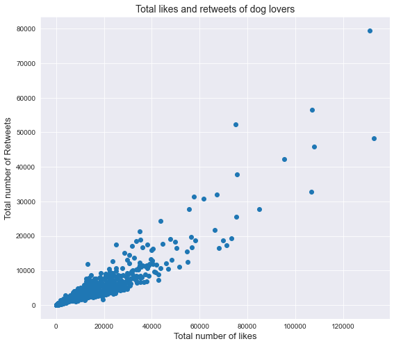

```python
# Scatter plot showing  the correlation of total likes and total retweets.

sns.set_style("darkgrid")
plt.figure(figsize=(9,8))
plt.scatter(x= dog["total_likes"], y=dog["total_retweets"])
plt.title("Total likes and retweets of dog lovers", fontsize= 14)
plt.xlabel("Total number of likes", fontsize= 13)
plt.ylabel("Total number of Retweets", fontsize= 13)
plt.show()
```

### Insight:

I found that the there is a positive correlation between the total number of likes and retweets of dog tweets among dog lovers.

This means that dog lovers tend to retweet the dog tweets that they liked more. They are more likely to retweet a dog tweet when they like it.

### Research Question 2

#### Which group of dogs did dog lovers retweeted more?

- #### Good or bad dogs?

#### Note:

I will answer this question by plotting the dog ratings and total number of retweets per dog on a scatter plot to see if there is a positive correlaton between them.

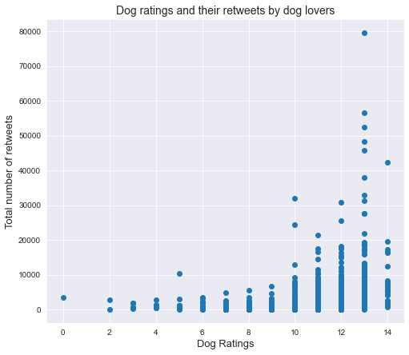

```python
# Scatter plot showing  the correlation of the ratings and total retweets.

plt.figure(figsize=(8,7))
plt.scatter(x= dog["rating(over_10)"], y=dog["total_retweets"])
plt.title("Dog ratings and their retweets by dog lovers", fontsize= 14)
plt.xlabel("Dog Ratings", fontsize= 13)
plt.ylabel("Total number of retweets", fontsize= 13)
plt.show()
```

### Insight:

From the scatter plot, I found that the there is a positive correlation between the dog ratings and total number of retweets among dog lovers.

This means that dog lovers tend to retweet the tweets about good dogs more than they did with bad dogs. This confirm that the dog poster rating align with dog lovers.

It can also be deduced from the above visualization that the higher the dog rating, the more the retweets.

### Research Question 3

#### Which group of dogs did dog lovers liked more?

- #### Good dogs or bad dogs?

#### Note:

I will answer this question by plotting the ratings of each dog and their total number of likes on a scatter plot to see if there is a positive correlaton between them.

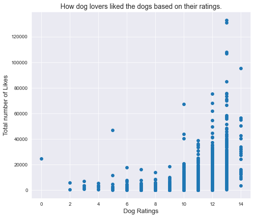

```python
# Scatter plot showing  the correlation of the dog likes and total retweets.

plt.figure(figsize=(8,7))
plt.scatter(x= dog["rating(over_10)"], y=dog["total_likes"])
plt.title("How dog lovers liked the dogs based on their ratings.", fontsize= 14)
plt.xlabel("Dog Ratings", fontsize= 13)
plt.ylabel("Total number of Likes", fontsize= 13)
plt.show()
```

### Insight:

From the scatter plot, I found that the there is a positive correlation between the dog ratings and total number of likes among dog lovers. The higher the dog rating, the higher the number of likes.

The dog likes went to the highest levels with dogs with ratings of 10 and above(good dogs). In fact, the likes went as high as over 120,000 likes for a few dogs with 13 over 10 ratings.

This means that dog lovers tend to like the tweets about good dogs more than they did with bad dogs. This also confirms that the dog poster ratings align with dog lovers.

### Research Question 4

### 4. What is the average rating of both groups of dogs?

### What is the average rating for good dogs?

### Note:

- I will first take the mask of good and bad dogs.
- Then, I will find the average ratings of both dog groups.

```python
# dataframe for good and bad dogs.
good_dog = dog[dog["rating(over_10)"] >= 10]
bad_dog = dog[dog["rating(over_10)"] < 10]
```

```python
# Print first five rows
good_dog.head()
```

|  | tweet_id | rating(over_10) | total_likes | total_retweets | dog_breed |
| --- | --- | --- | --- | --- | --- |
| 5 | 666050758794694657 | 10 | 136 | 60 | Bernese Mountain Dog |
| 6 | 666055525042405380 | 10 | 448 | 261 | Chow |
| 9 | 666063827256086533 | 10 | 496 | 232 | Golden Retriever |
| 11 | 666073100786774016 | 10 | 335 | 174 | Walker Hound |
| 15 | 666102155909144576 | 11 | 81 | 16 | English Setter |

```python
# Print first five rows
bad_dog.head()
```

|  | tweet_id | rating(over_10) | total_likes | total_retweets | dog_breed |
| --- | --- | --- | --- | --- | --- |
| 0 | 666020888022790149 | 8 | 2535 | 532 | Welsh Springer Spaniel |
| 1 | 666029285002620928 | 7 | 132 | 48 | Redbone |
| 2 | 666033412701032449 | 9 | 128 | 47 | German Shepherd |
| 3 | 666044226329800704 | 6 | 311 | 147 | Rhodesian Ridgeback |
| 4 | 666049248165822465 | 5 | 111 | 41 | Miniature Pinscher |

#### Average rating of good dogs.

```python
# Find the average ratings of good dogs.
good_dog_rating = np.round(good_dog["rating(over_10)"].mean())
```

```python
# show result
good_dog_rating
```

```
11.0
```

#### Average rating for bad dogs

```python
# Average rating for bad dogs
bad_dog_rating  = np.round(bad_dog["rating(over_10)"].mean())
```

```python
# show result

bad_dog_rating
```

```
8.0
```

#### Plot the average ratings of both groups on a bar chart.

```python
# Functions to add value labels to a bar char.

def value_label(x,y):
    for i in x:
        plt.text(i, y[i]+0.2, y[i], ha="center")


# Please, note that this function will be called multiple times to add value label to bar charts.
```

```python
# tick value for the x-axis of the bar chart

base = np.arange(2)

# labels of x-ticks of the bar chart
tick = ["Good dogs", "Bad dogs"]
```

```python
# tick value for the y-axis of the bar chart

avg_rating = [good_dog_rating, bad_dog_rating]
```

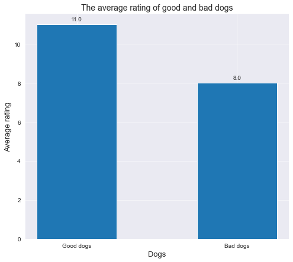

```python
# Bar chart showing the average ratings of both good and bad dogs.

plt.figure(figsize=(8,7))
plt.bar(base, avg_rating, width=0.5)
plt.title("The average rating of good and bad dogs", fontsize= 14)
plt.xlabel("Dogs", fontsize= 13)
plt.ylabel("Average rating", fontsize= 13)
plt.xticks(base, tick)

# Call function to add value labels to chart.
value_label(base, avg_rating)

plt.show()
```

### Insight:

The Good dogs have an average rating of 11 while bad dogs have an average rating of 8.

Good dogs are really good because they have ratings above 10.

Bad dogs are bad because they have an average rating below 10.

### Research Question 5

#### Which group of dogs has more likes among dog lovers?

- #### Good or bad dogs?

#### Average likes for good dog

```python
# Average likes for good dogs.

good_dog_likes = np.round(good_dog["total_likes"].mean())
```

```python
# show result
good_dog_likes
```

```
10547.0
```

#### Average likes for bad dogs

```python
# Average likes for bad dogs.

bad_dog_likes = np.round(bad_dog["total_likes"].mean())
```

```python
bad_dog_likes
```

```
2767.0
```

#### Note:

I will plot the result on a bar chart in the next research question section.

```python
# tick values of y axis.
avg_likes = [good_dog_likes, bad_dog_likes]
```

## Research Question 6

### Which dog group did dog lovers retweeted more?

- #### Good or bad dogs?

#### Note:

I will answer the question by finding the average retweet for good and bad dogs. I will then show the result on a bar chart.

#### Average retweet for good dogs.

```python
# Average retweet for good dogs.

good_dog_retweets = np.round(good_dog["total_retweets"].mean())
```

```python
# Show result
good_dog_retweets
```

```
3195.0
```

#### Average retweet for bad breeds

```python
# Average retweet for bad dogs.

bad_dog_retweets = np.round(bad_dog["total_retweets"].mean())
```

```python
# Show result

bad_dog_retweets
```

```
917.0
```

#### Plot the average likes and retweets of good and bad dogs on a bar chart.

```python
avg_retweets = [good_dog_retweets, bad_dog_retweets]
```

```python
width=0.2
```

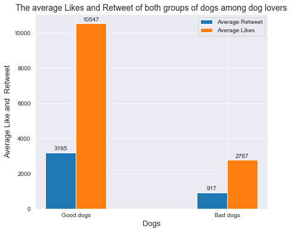

```python
# Bar chart showing the average retweets of good and bad dogs among dog lovers.

plt.figure(figsize=(7,6))
avg_retweets_bar = plt.bar(base-width/2, avg_retweets, width, label="Average Retweet")
avg_likes_bar = plt.bar(base+width/2, avg_likes, width, label="Average Likes")

# Add value label to the bar chart.
plt.bar_label(avg_retweets_bar, padding=2)
plt.bar_label(avg_likes_bar, padding=2)


plt.title("The average Likes and Retweet of both groups of dogs among dog lovers", fontsize= 14)
plt.xlabel("Dogs", fontsize= 13)
plt.ylabel("Average Like and  Retweet", fontsize= 13)
plt.xticks(base, tick)


plt.legend()

plt.show()
```

#### Insight 1:

From the bar chart, dog lovers retweeted good dogs more than bad dogs. Good dogs have an average retweet of 3,195 while only 917 retweets for bad dogs. The difference is very clear. Dog lovers seem to agree with the opinion of the dog rater again.

Rememeber, it's the dog poster that determines which dog is good and which is bad. He gives rating 10 and above for good dogs and rates dogs he considered bad 9 and below.

#### Insight 2:

It can also be deduced that dog lovers liked good dogs more than bad dogs. Good dogs have an average likes of 10,547 while 2767 likes for bad dogs. The difference is very clear. Dog lovers seem to agree with the opinion of the dog rater.

Rememeber, it's the dog poster that determines which dog is good and which is bad. He gives rating 10 and above for good dogs and rates dogs he considered bad 9 and below.

## Research Question 7

### What breed is the dog with the highest number of likes?

- #### Are dogs of this breed generally good dogs?

```python
# Record of dog breed with the highest number of likes.

dog[dog["total_likes"] == dog["total_likes"].max()]
```

|  | tweet_id | rating(over_10) | total_likes | total_retweets | dog_breed |
| --- | --- | --- | --- | --- | --- |
| 1387 | 822872901745569793 | 13 | 132810 | 48265 | Lakeland Terrier |

#### Insight:

Dog lovers liked Lakeland Terrier the most. Note that this record is only for dog lovers that hit the like button on Lakeland Terrier breed. 132,810 people liked a dog posted with the tweet_id of 822872901745569793.

### Is the breed generally a good breed?

```python
# Records of dogs that belong to Lakeland Terrier breed.

lakeland_retriever = dog[dog["dog_breed"].str.contains("Lakeland Terrier")]
```

```python
# Average rating of dogs that are of Lakeland Terrier breed.
np.round(lakeland_retriever["rating(over_10)"].mean(),2)
```

```
10.44
```

#### Insight:

From the analysis, I can deduce that dogs that are of Lakeland Terrier breed are generally good dogs. This is because their average rating is above 10.

Please, note that this result is based on average. There are also bad dogs among them. But there are more good dogs than bad dogs among the breed.

## Research Question 8

### Which dog breed did dog lovers liked and retweeted the least?

- #### Are dogs of the breed generally bad dogs.

```python
# Record of dog with the lowest number of likes.
dog[dog["total_likes"] == dog["total_likes"].min()]
```

|  | tweet_id | rating(over_10) | total_likes | total_retweets | dog_breed |
| --- | --- | --- | --- | --- | --- |
| 15 | 666102155909144576 | 11 | 81 | 16 | English Setter |

```python
# Record of dog with the lowest number of retweets.
dog[dog["total_retweets"] == dog["total_retweets"].min()]
```

|  | tweet_id | rating(over_10) | total_likes | total_retweets | dog_breed |
| --- | --- | --- | --- | --- | --- |
| 15 | 666102155909144576 | 11 | 81 | 16 | English Setter |

#### Insight:

From the above result, I found that the dog with the tweet id of 666102155909144576 was liked and retweeted the least by dog lovers. The dog belong to the English Setter breed.

#### Are dogs of the breed(English Setter) generally good or dogs.

```python
# Record of dogs that belong to the English Setter breed.

english_setter = dog[dog["dog_breed"].str.contains("English Setter")]
```

```python
#  The average rating of dogs that are of English Setter breed.

np.round(english_setter["rating(over_10)"].mean(), 2)
```

```
9.88
```

#### Insight:

From the result above, I can deduce that dogs that are of English Setter breed are generally bad dogs. This is because their average rating is below 10.

Please, note that this result is based on average. There are also good dogs among them. But it appears there are more bad dogs than good dogs among the breed.

### Conclusion

- Dog with high ratings tend to be liked and retweeted more by dog lovers.
- Dogs with low ratings are retweeted less by dog lovers.
- Dog lovers sentiment seem to agree with the ratings of the dog poster.
- It appears that if the dog rating is very low or below 10, it’s more likely to be retweeted and liked less by dog lovers.

### Limitation:

In this project, I did not explore the date in which dogs ratings were tweeted. It’s important to know that the number of followers WeRateDogs have at the time of tweeting could impact the number of likes and retweets. Dogs posted in 2016 and 2017 are more likely to have more likes than dogs posted in 2015. That’s because the number of followers has multiplied over the years. Dogs posted in 2015 are more likely to receive low reactions because the account was created in the same year. Hence, I couldn’t draw conclusions on such dogs.

I must also mention that my analysis is limited and do not draw absolute conclusion on why dogs receives more reaction than other dogs. Further analysis needs to be carried out through advanced processes such as machine learning in order to draw conclusion on how dogs with low reactions differ from dogs with high reactions from dog lovers.